# Flight Delays Prediction / Analytics

## Are there critical links in the system?

Now let’s take e.g: Let’s Say. Delays (Both ArrDelay and DepDelay) in Origin at a given time can cause Delays in later time at Dependent Dest.

So need to have mean delays by time at both Upstream Airports and downstream airports and join the.

### Defining downstream Airport

```r
library(dplyr)

DownstreamAirport <- dplyr::select (tripsplaneairports, Origin, Dest, DepDelay, ArrDelay, DepTimeofday, ArrTimeofday, ArrHour, DepHour )

DownstreamAirportDepDelay <- DownstreamAirport %>%
  group_by( Dest, ArrHour  ) %>%
  summarise( DSAPDepDelay = mean(DepDelay))

DownstreamAirportArrDelay <- DownstreamAirport %>%
  group_by( Origin, DepHour  ) %>%
  summarise( DSAPArrDelay = mean(ArrDelay))

# Now lets join
DownstreamAirportDelays <- merge(x=DownstreamAirportDepDelay, y=DownstreamAirportArrDelay, by.x = c("Dest", "ArrHour"), by.y= c("Origin", "DepHour"))

colnames(DownstreamAirportDelays) <- c("DownStreamAirport",  "Hour", "DSAPDepDelay", "DSAPArrDelay" )
head(DownstreamAirportDelays)
```

```
##   DownStreamAirport Hour DSAPDepDelay DSAPArrDelay
## 1               ABE   12    -1.250000    20.111111
## 2               ABE   16    32.777778   -15.000000
## 3               ABE   17     0.000000    10.066667
## 4               ABE    9    -3.000000    -6.333333
## 5               ABQ   10     7.538462     2.600000
## 6               ABQ   11    11.423077     4.552632
```

### Defining upstream Airport

```r
# Upstream Airport
UpstreamAp <- dplyr::select (tripsplaneairports, Origin, Dest, DepDelay, ArrDelay, DepTimeofday, ArrTimeofday, ArrHour, DepHour )

  UpstreamAirportDepDelay <- UpstreamAp %>%
    group_by( Dest, ArrHour  ) %>%
    summarise( DSAPDepDelay = mean(DepDelay))

  UpstreamAirportArrDelay <- UpstreamAp %>%
    group_by( Origin, DepHour  ) %>%
    summarise( DSAPArrDelay = mean(ArrDelay))

  # Now lets join

  UpstreamAirportDelays <- merge(x=UpstreamAirportDepDelay, y=UpstreamAirportArrDelay, by.x = c("Dest", "ArrHour"), by.y= c("Origin", "DepHour"))

  colnames(UpstreamAirportDelays) <- c("UpstreamAirport",  "UpstreamHour", "UPAPDepDelay", "UPAPArrDelay" )
  head(UpstreamAirportDelays)
```

```
##   UpstreamAirport UpstreamHour UPAPDepDelay UPAPArrDelay
## 1             ABE           12    -1.250000    20.111111
## 2             ABE           16    32.777778   -15.000000
## 3             ABE           17     0.000000    10.066667
## 4             ABE            9    -3.000000    -6.333333
## 5             ABQ           10     7.538462     2.600000
## 6             ABQ           11    11.423077     4.552632
```

### Linking upstream and downstream Airports

```r
# Link between downstream airport and upstream airport
UpstreamDownStreamLink <- UpstreamAp %>%
  group_by( Origin, Dest, DepHour, ArrHour  ) %>%
  summarise( MeanDepDelay = mean(DepDelay), MeanArrDelay= mean(ArrDelay))

# Linking Downstream Airport and Link table
DownStreamUpstreamDelaySummary <- merge(x=DownstreamAirportDelays, y=UpstreamDownStreamLink, by.x = c("DownStreamAirport", "Hour"), by.y= c("Dest", "ArrHour")) # The Link is always #ArrHour

head(DownStreamUpstreamDelaySummary)
```

```
##   DownStreamAirport Hour DSAPDepDelay DSAPArrDelay Origin DepHour
## 1               ABE   12     -1.25000     20.11111    CVG      11
## 2               ABE   12     -1.25000     20.11111    CLE      11
## 3               ABE   16     32.77778    -15.00000    CLE      15
## 4               ABE   16     32.77778    -15.00000    ATL      14
## 5               ABE   16     32.77778    -15.00000    ORD      13
## 6               ABE   16     32.77778    -15.00000    CVG      15
##   MeanDepDelay MeanArrDelay
## 1     1.333333    -6.666667
## 2    -9.000000   -12.000000
## 3   -10.000000    -8.000000
## 4    28.000000    30.000000
## 5    46.166667    44.000000
## 6     0.000000   -12.000000
```

```r
# Now link to upstream airport

DownStreamUpstreamDelaySummaryfinal <- merge( x=UpstreamAirportDelays, y=DownStreamUpstreamDelaySummary, by.y = c("Origin", "DepHour") , by.x= c("UpstreamAirport",  "UpstreamHour"))

CascadingSummary <- DownStreamUpstreamDelaySummaryfinal %>%
                    group_by(DownStreamAirport, Hour )  %>%
                    summarize(DSAPDelay = mean(DSAPDepDelay+DSAPArrDelay), UPAPDelay = mean(UPAPDepDelay+UPAPDepDelay), MeanDSAPDepDelay = mean(DSAPDepDelay), MeanDSAPArrDelay = mean(DSAPArrDelay) , MeanUPAPDepDelay =  mean(UPAPDepDelay), MeanUPAPDelay = mean(UPAPArrDelay) ) %>%
                    filter (DSAPDelay > -121 , DSAPDelay < 121 , UPAPDelay > -121  , UPAPDelay < 121 )
                    # Filering to avoid outliers... some which are more then 300min delays, these have different #reasons...

head(CascadingSummary)
```

```
## # A tibble: 6 x 8
## # Groups:   DownStreamAirport [2]
##   DownStreamAirport  Hour DSAPDelay UPAPDelay MeanDSAPDepDelay
##              <fctr> <dbl>     <dbl>     <dbl>            <dbl>
## 1               ABE     9 -9.333333 -1.333333        -3.000000
## 2               ABE    12 18.861111  9.736364        -1.250000
## 3               ABE    16 17.777778 25.140805        32.777778
## 4               ABE    17 10.066667 28.632345         0.000000
## 5               ABQ     7  6.007576 -3.760000        -2.750000
## 6               ABQ     8 77.000000  2.293842         7.583333
## # ... with 3 more variables: MeanDSAPArrDelay <dbl>,
## #   MeanUPAPDepDelay <dbl>, MeanUPAPDelay <dbl>
```

### Now let’s plot to see the relationship

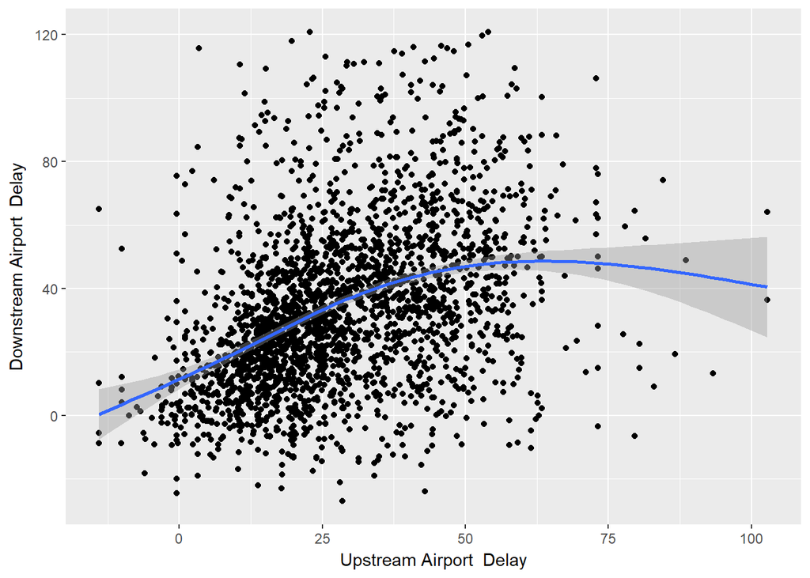

```r
ggplot(CascadingSummary, aes(UPAPDelay, DSAPDelay)) + geom_point() + geom_smooth() + xlab("Upstream Airport  Delay") + ylab("Downstream Airport  Delay")
```

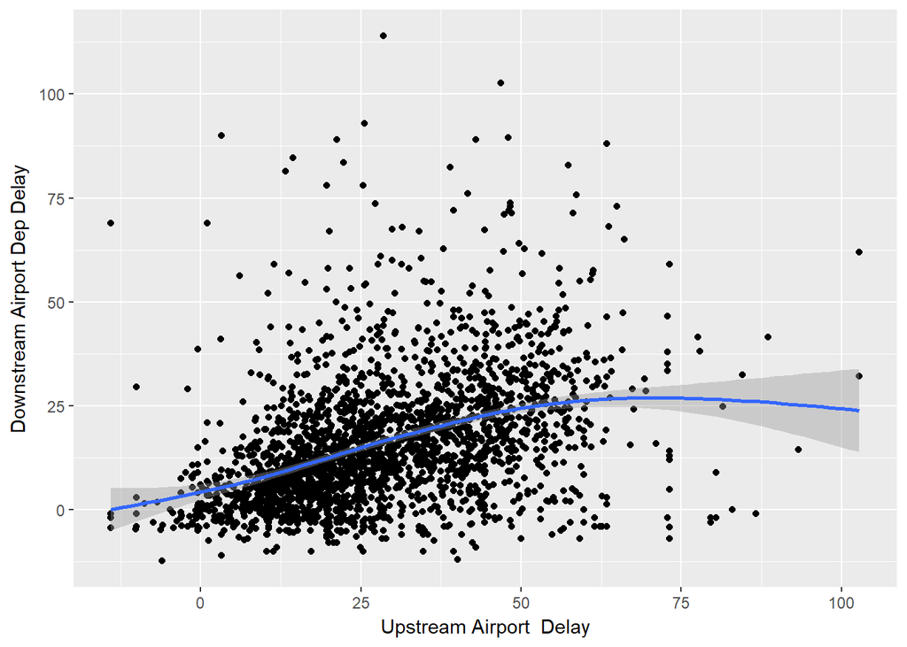

```r
ggplot(CascadingSummary, aes(UPAPDelay, MeanDSAPDepDelay)) + geom_point() + geom_smooth() + xlab("Upstream Airport  Delay") + ylab("Downstream Airport Dep Delay")
```

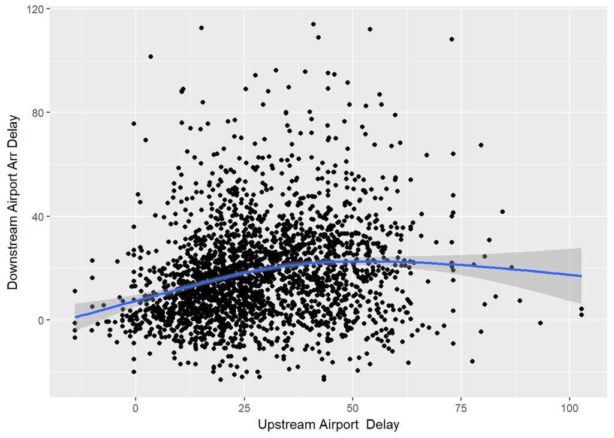

```r
ggplot(CascadingSummary, aes(UPAPDelay, MeanDSAPArrDelay)) + geom_point() + geom_smooth() + xlab("Upstream Airport  Delay") + ylab("Downstream Airport Arr Delay")
```

```r
# We can clearly see relationship
# Let's look into co-relation

CascadingSummary_for_cor <- CascadingSummary[,3:8]

head(CascadingSummary_for_cor)
```

```
## # A tibble: 6 x 6
##   DSAPDelay UPAPDelay MeanDSAPDepDelay MeanDSAPArrDelay MeanUPAPDepDelay
##       <dbl>     <dbl>            <dbl>            <dbl>            <dbl>
## 1 -9.333333 -1.333333        -3.000000        -6.333333       -0.6666667
## 2 18.861111  9.736364        -1.250000        20.111111        4.8681818
## 3 17.777778 25.140805        32.777778       -15.000000       12.5704024
## 4 10.066667 28.632345         0.000000        10.066667       14.3161725
## 5  6.007576 -3.760000        -2.750000         8.757576       -1.8800000
## 6 77.000000  2.293842         7.583333        69.416667        1.1469212
## # ... with 1 more variables: MeanUPAPDelay <dbl>
```

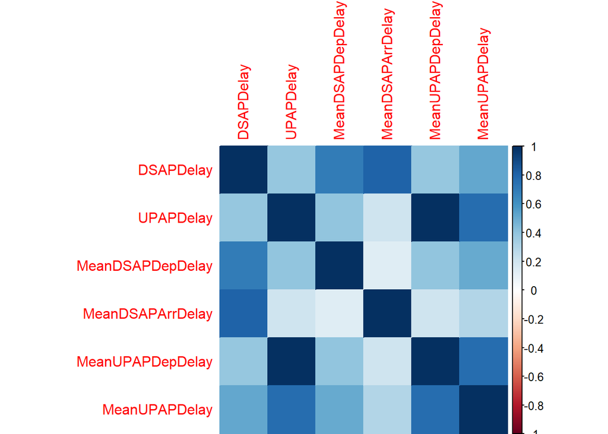

```r
cascad_cor <- cor(CascadingSummary_for_cor, method="pearson")
# Let's plot the co-relation matix
corrplot::corrplot(cascad_cor, method="color")
```

```r
# This clearly provides co-relation between the variables.
cor(CascadingSummary$DSAPDelay, CascadingSummary$UPAPDelay )
```

```
## [1] 0.3878908
```

### We can see positive co-relation ~0.40, It may be a good predictor. This would definitely improve if we add more parameters such as day of the week etc…

## Let’s say we want to include UPAPDelay as parameter for predicting Delays. We can write a function first to get the Upstream Delay (UPAP Delay). This function we should restrict to may be max week worth of data to get mean delay. As we move closer to departure, we can then just take that days delay and predict more accurately.

```r
fun_cascadingAirportDelay <- function(Airportval, Traveldateval, Hourval,  Timeframedaysval, Delaytypeval ="Dep"  ) {

  library(lubridate)

  Cascading_InterestedData <- tripsplaneairports %>%
    filter( TravelDate > (ymd(Traveldateval) - days(Timeframedaysval) ), TravelDate <= Traveldateval )

    #Cascading_InterestedData <- tripsplaneairports %>%
    #filter( TravelDate > (ymd("2007-10-10") - days(15) ), TravelDate <= "2007-10-10") # %>%
      #filter (Dest == "ABE")

  nrow(Cascading_InterestedData)

  head(Cascading_InterestedData)


    DownstreamAirportDepDelay <- Cascading_InterestedData %>%
    filter( Dest == Airportval , ArrHour == Hourval ) %>%
    group_by( Dest, ArrHour  ) %>%
    summarise( DSAPDepDelay = mean(DepDelay))

  DownstreamAirportArrDelay <- Cascading_InterestedData %>%
    filter( Origin == Airportval , DepHour == Hourval ) %>%
    group_by( Origin, DepHour  ) %>%
    summarise( DSAPArrDelay = mean(ArrDelay))

  # Now lets join

  DownstreamAirportDelays <- merge(x=DownstreamAirportDepDelay, y=DownstreamAirportArrDelay, by.x = c("Dest", "ArrHour"), by.y= c("Origin", "DepHour"))

  colnames(DownstreamAirportDelays) <- c("DownStreamAirport",  "Hour", "DSAPDepDelay", "DSAPArrDelay" )

  # Upstream Airport

  UpstreamAp <- dplyr::select (Cascading_InterestedData, Origin, Dest, DepDelay, ArrDelay, DepTimeofday, ArrTimeofday, ArrHour, DepHour )

  UpstreamAirportDepDelay <- UpstreamAp %>%
    group_by( Dest, ArrHour  ) %>%
    summarise( DSAPDepDelay = mean(DepDelay))

  UpstreamAirportArrDelay <- UpstreamAp %>%
    group_by( Origin, DepHour  ) %>%
    summarise( DSAPArrDelay = mean(ArrDelay))

  # Now lets join

  UpstreamAirportDelays <- merge(x=UpstreamAirportDepDelay, y=UpstreamAirportArrDelay, by.x = c("Dest", "ArrHour"), by.y= c("Origin", "DepHour"))

  colnames(UpstreamAirportDelays) <- c("UpstreamAirport",  "UpstreamHour", "UPAPDepDelay", "UPAPArrDelay" )

  # Link between downstream airport and upstream airport

  UpstreamDownStreamLink <- UpstreamAp %>%
    group_by( Origin, Dest, DepHour, ArrHour  ) %>%
    summarise( MeanDepDelay = mean(DepDelay), MeanArrDelay= mean(ArrDelay))


  # Linking Downstream Airport and Link table
  DownStreamUpstreamDelaySummary <- merge(x=DownstreamAirportDelays, y=UpstreamDownStreamLink, by.x = c("DownStreamAirport", "Hour"), by.y= c("Dest", "ArrHour"))

  # Now link to upstream airport

  DownStreamUpstreamDelaySummaryfinal <- merge( x=UpstreamAirportDelays, y=DownStreamUpstreamDelaySummary, by.y = c("Origin", "DepHour") , by.x= c("UpstreamAirport",  "UpstreamHour"))

  head(DownStreamUpstreamDelaySummaryfinal)

  CascadingSummary <- DownStreamUpstreamDelaySummaryfinal %>%
    group_by(DownStreamAirport, Hour )  %>%
    summarize(UPAPDelay = mean(UPAPArrDelay+UPAPDepDelay),  meanUPAPDepdelay = mean(UPAPDepDelay), meanUPAPArrDelay = mean(UPAPArrDelay) )

  CascadingSummary[is.na(CascadingSummary)] <- 0 # Just replacing Nas with zero

  #result <- c(CascadingSummary$meanUPAPDepdelay,CascadingSummary$meanUPAPArrDelay )
  #return(result)

  return (if(Delaytypeval=="Dep") {CascadingSummary$meanUPAPDepdelay} else {CascadingSummary$meanUPAPArrDelay})

#return( if(is.empty(CascadingSummary$meanUPAPDepdelay)) 0 else CascadingSummary$meanUPAPDepdelay  , #if(is.empty(CascadingSummary$meanUPAPArrDelay)) 0 else CascadingSummary$meanUPAPArrDelay )

}
```

#### Now we can run the function to see how we are able to get MeanUpstreamAirport Delay, By passing Dependent Airport and an hour of interest.

```r
#Parameters required:    Airportval, Traveldateval, Hourval, Timeframeval = "weeks"
fun_cascadingAirportDelay ("LAS", "2008-10-10",  12, 7, "Dep" )
```

```
## numeric(0)
```

```r
fun_cascadingAirportDelay ("LAS", "2007-10-10",  10, 7 )
```

```
## [1] -1.5
```

```r
fun_cascadingAirportDelay ("SLC", "2007-10-10",  10, 7, "Arr" )
```

```
## numeric(0)
```

#### We can use this to create additional feature in the data set. Since the co-relation seems not so great. We are leaving this here. However, in-live systems we can use this to predict delays in-realtime.

#### This can be used to predict flight delays closer to the time of flying because that is the time the delays in Upstream Airports will be available.

###### This ends our Analysis… Below we try to explore the same concepts on Big Data Spark systems.

## Running same analysis on BigData/Spark

#### Connecting to Spark Local server

```r
sc <- spark_connect(master = "local")
```

## Exploratory Data Analysis

### Carrier on-time performance

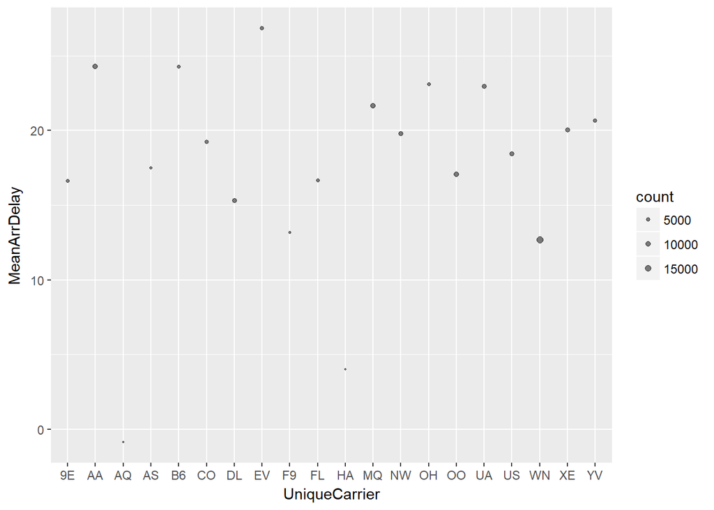

```r
tripsdelayCarrier <- trips_tbl2 %>%
  group_by(UniqueCarrier) %>%
  summarise(count=n(), MeanArrDelay=mean(ArrDelay), MeanDepdelay=mean(DepDelay)) %>%
  filter (count > 20 ) %>%
  collect
#Plot the delay

ggplot(tripsdelayCarrier, aes(UniqueCarrier, MeanArrDelay)) + geom_point(aes(size=count), alpha=1/2) + scale_size_area(max_size = 2)
```

### Delays in each month

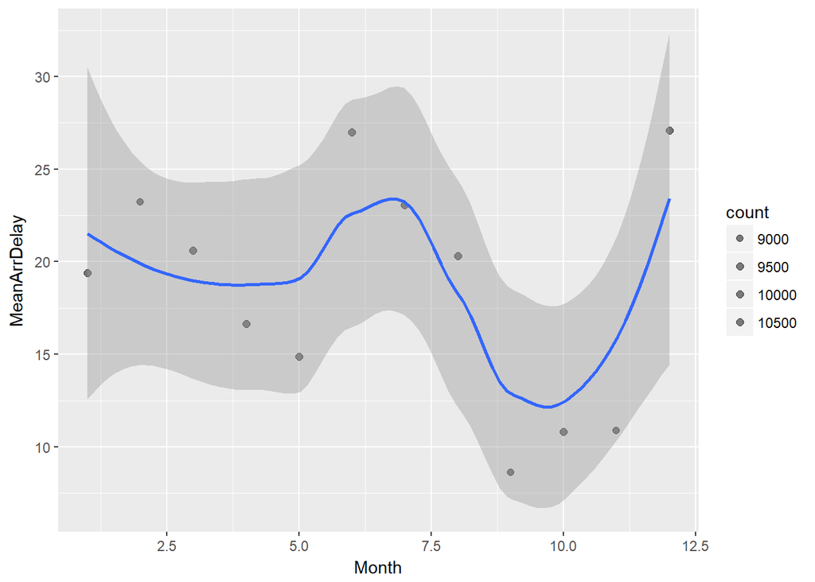

```r
tripsdelayMonth <- trips_tbl2 %>%
  group_by(Month) %>%
  summarise(count=n(), MeanArrDelay=mean(ArrDelay), MeanDepdelay=mean(DepDelay)) %>%
  filter (count > 20 ) %>%
  collect
#Plot the delay

ggplot(tripsdelayMonth, aes(Month, MeanArrDelay)) + geom_point(aes(size=count), alpha=1/2) + geom_smooth() + scale_size_area(max_size = 2)
```

### Linear regression with Spark ML Lib (Just an example)

Summarize the linear model

```r
summary(mlfit1)
```

```
## Call: ml_linear_regression(., DepDelay ~ WeatherDelay + Month)
##
## Deviance Residuals::
##     Min      1Q  Median      3Q     Max
## -183.99  -20.27  -16.11    3.25 1501.17
##
## Coefficients:
##               Estimate Std. Error t value  Pr(>|t|)
## (Intercept)  18.784568   0.310935 60.4131 < 2.2e-16 ***
## WeatherDelay  1.018458   0.011502 88.5498 < 2.2e-16 ***
## Month        -0.279624   0.042433 -6.5898 4.429e-11 ***
## ---
## Signif. codes:  0 '***' 0.001 '**' 0.01 '*' 0.05 '.' 0.1 ' ' 1
##
## R-Squared: 0.08601
## Root Mean Squared Error: 42.22
```

From results it’s clear that we don’t necessirly have choosen all the features. We can continue same steps we did on R on spark environment as well and surely we will have similar results. Leaving this here given my Spark session terminates frequently and RStudio behaving not as expected.

## Conclusion:

It’s a great experience to know what goes behind the screen in flying….. so much fun… and so much more to do before this can be used in real-time.

### Future imporovements and suggestios

1. We have taken only sample data hence peformance possibly be enhanced by running same analysis on Spark. But steps wouldn’t change much.
2. We could also pre-define what is delay, i.e more then certain minutes as delay (e.g: more then 10min as delay) and turn this into Classification problem. And once classified then start predicting the delay minutes using linear regression. To check if there is alternates that can add value.
3. Airport Cascading delays, precalculated transformed features can be used in model prediction for realtime delays.
4. Before using this model in production, there is some work to be done listed above. And ofcourse, we need to modularize the code and create functions for all repetative tasks. Also, create functions to answer questions.